# Data Science Capstone Final Project

4/20/2020

## Overview of the project

- The purpose of the project is to creating an application based on a predictive model for text.
- Given a word or phrase as input, the application will try to predict the next word, similar to the way most smart phone keyboards are implemented today using the technology of Swiftkey.
- The predictive model will be trained using a corpus, a collection of written texts, called the HC Corpora which has been filtered by language

## Prediction Model

- The prediction model uses the principles applying to text mining in R. The following are the Key steps involved in the prediction model.
- As an input, it takes raw text files for model training
- Clean the raw data, separate into 2, 3, 4, 5, and 6 word n grams and save as tibbles
- Sort the n grams tibbles by frequency and save the data as .rds files
- n grams function uses a back-off type prediction model
  - User supplies an input phrase
  - Model uses last 5, 4, 3, 2, or 1 words to predict the best 6th, 5th, 4th, 3rd, or 2nd match in the data and predicts next word

## THE SHINY APPLICATION

- The Shiny app allows the prediction of the next possible word of a sentence.
- The user entered the text in an input box, and in the other one, the app returns the most probability word to be used.
- The predicted word is obtained from the n-grams matrices, comparing it with tokenized frequency of 2, 3 and 4 grams sequences.
- While entering the text, the field with the predicted next word refreshes instantaneously, and then the predicted word is then provided for the user’s choice.

## THE APP USER INTERFACE

Screenshot of the user interface with the directions to provide a sentence or a word and get the prediction of the next likely word.

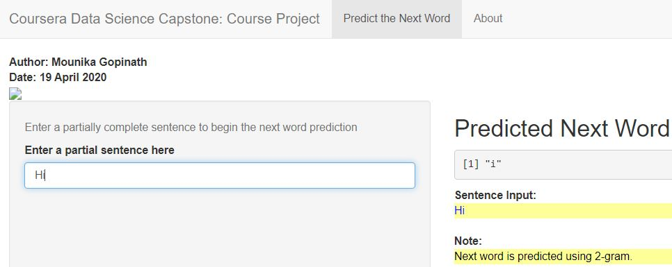